# 02 Python od podstaw - środowiska programistyczne

*Kamil Bartocha*

## Edytor kodu źródłowego

- **Program komputerowy** wspomagający pisanie **kodu źródłowego**
- Rozpoznawanie i wyróżnianie składni (np. przez nadawanie koloru czy kroju czcionki) i zapisywanie w odpowiednim formacie
- Często - dodatkowe funkcję jak:
  - Autouzupełnianie kodu
  - Możliwość pisania makr
  - Itp.
- Może:
  - Stanowić samodzielny program
  - Być częścią IDE

### Popularne edytory programistyczne

- **Atom**
- **Eclipse** (wiele platform, w tym Linux, macOS, Windows)
- **Emacs** (wiele platform, w tym Unix, Linux, macOS, Windows)
- **Notepad++** (Windows)
- **Sublime Text**
- **vi/vim** (wiele platform, w tym Unix, Linux, macOS, Windows)
- **Visual Studio Code** (wiele platform, w tym Linux, macOS, Windows)

## IDLE - wbudowany edytor kodu Pythona

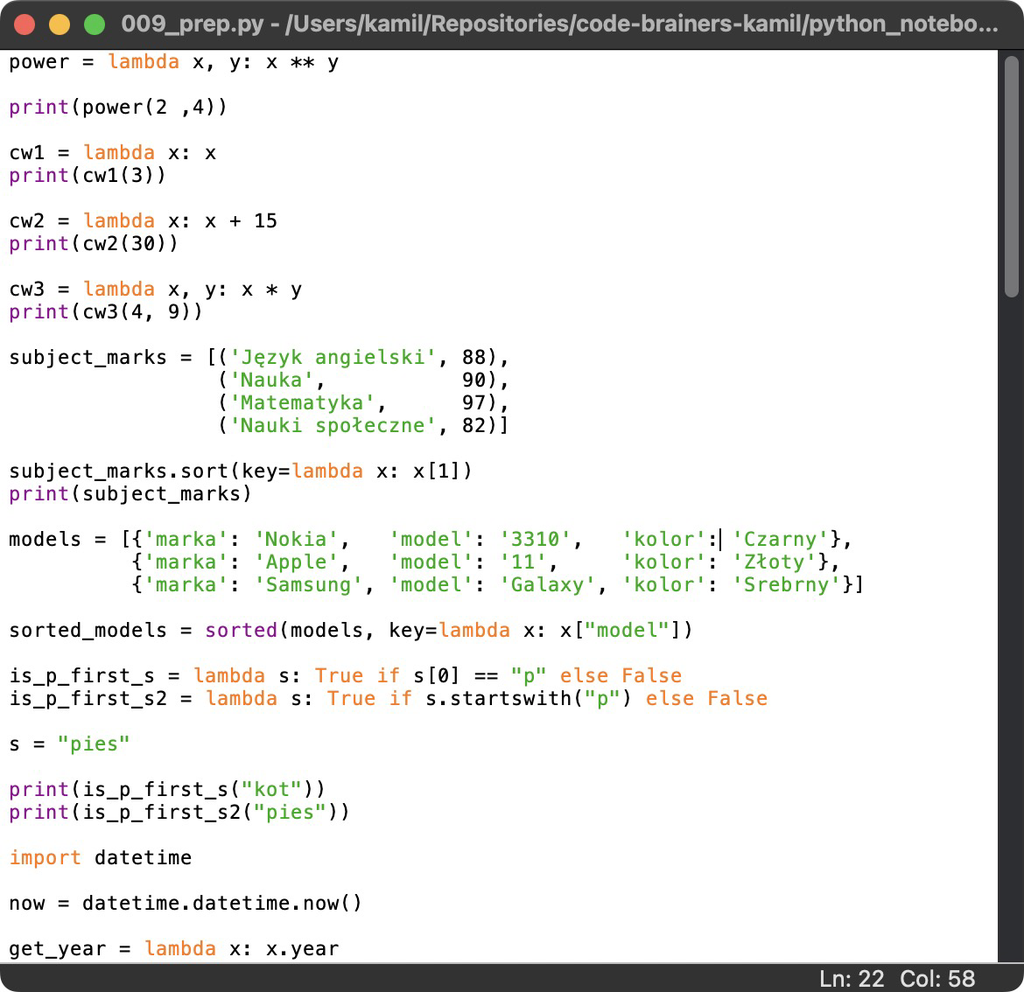

## Sublime Text

- **Edytor tekstu** zorientowany dla **programisty**:
  - **Wieloplatformowy**
  - Rozbudowany
  - Wysoce konfigurowalny
- Można pobrać oraz używać za darmo (jednak w bezpłatnej wersji wyświetlanie się komunikatu zachęcający do rejestracji pełnej wersji programu)
- Strona internetowa: http://www.sublimetext.com

### Możliwości - niektóre z wbudowanych funkcji edytora

#### Interfejs użytkownika

- Podział okna
- Karty - otwieranie wielu plików równocześnie
- Mini-mapa - podgląd całego kodu źródłowego
- Edycja pełnoekranowa
- Podświetlanie składni
- Schematy kolorów
- Auto-zapis

[figure not shown]

#### Edycja

- Multi-select i multi-edit
- Edycja kolumnowa
- Szukanie i zastępowanie przy pomocy **wyrażeń regularnych**
- Zakładki
- Parowanie nawiasów
- Obsługa projektów

#### Adaptacja

- Pełna możliwość redefinicji **skrótów klawiszowych** oraz menu
- **Wtyczki**

#### Automatyzacja

- **Makra**
- Snippety
- Autouzupełnianie składni
- Powtarzanie ostatniej czynności

#### Hello world (ang. *Witaj świecie*) w edytorze kodu źródłowego

- Program, którego jedynym celem jest wypisanie na standardowym wyjściu:
  - Napisu `"Hello World!"`, lub
  - Innego prostego komunikatu
- Przykład:

```python
print('Hello world!')
```

```
Hello world!
```

- Program taki ma na celu jedynie demonstrację języka, środowiska bądź biblioteki, w której był napisany
- Nazwą tą określa się też wszystkie inne trywialne programy, dla których jedynym celem istnienia jest demonstrowanie sposobów programowania

#### Ćwiczenie: Hello world w Sublime Text

- Stwórz plik `hello.py` w Sublime Text
- Wpisz kod programu
- Uruchom:

```
python hello.py
Hello world!
```

## Zintegrowane środowisko programistyczne (ang. *Integrated Development Environment*, IDE)

**Program lub zespół programów (środowisko) służących do:**

- Tworzenia oprogramowania
- Modyfikowania oprogramowania
- Testowania oprogramowania
- Konserwacji oprogramowania

**Udostępnianie złożonej, wielorakiej funkcjonalności obejmującej:**

- Edycję **kodu źródłowego**
- **Kompilowanie** kodu źródłowego
- Tworzenie zasobów programu (tzn. formatek/ekranów/okien dialogowych, menu, raportów, elementów graficznych jak ikony, obrazy)
- Tworzenie **baz danych**, komponentów i innych

## Koncepcje środowiska programistycznego

### Środowisko jako osobny pakiet oprogramowania

**Przykłady:**

- Pakiet **Microsoft Visual Studio** (popularny na systemach rodziny Windows)
- IDE oparte na **Eclipse**, takie jak **Cedevelop** dla c++ czy **PyDev** dla pythona
- Programy **JetBrains – IntelliJ IDEA, WebStorm, PyCharm** i inne

## PyCharm

- **IDE** dla **języka programowania Python** firmy **JetBrains**
- Zapewnienie m.in.:
  - Edycji i analizy kodu źródłowego * Graficznego **debuggera**
  - Uruchamiania **testów jednostkowych**
  - Integrację z **systemem kontroli wersji**
  - Zintegrowany terminal/cmd

- Oprogramowanie wieloplatformowe pracujące na platformach systemowych:
  - Microsoft Windows
  - GNU/Linux
  - macOS
- Strona internetowa: https://www.jetbrains.com/pycharm/

### PyCharm – podstawowe funkcje

- Inteligentny edytor kodu z:
  - Podświetleniem składni dla:
    - Języka **Python**
  - Formatowaniem kodu
  - **Autouzupełnianiem** kodu źródłowego
  - Tworzeniem **snippetów**
- Wyposażenie edytora kodu w funkcję sprawdzania i weryfikacji błędów składniowych na bieżąco w trakcie pisania kodu
- **Refaktoryzacja** Pythona
- Edycja i wsparcie dla:
  - **HTML**
  - **CSS**
  - **JavaScript**
- Wsparcie dla innych **frameworków**:
  - **Flask**
  - Pyramid
  - Web2py
- Wsparcie dla **bibliotek**:
  - **SQLAlchemy**
  - **wxPython**
  - **PyQt**
  - **PyGTK**
- Programowanie na platformie **Google App Engine**
- Zintegrowane **testy jednostkowe** z **testami pokrycia**
- Graficzny **debugger** dla:
  - Pythona
  - Django
- Integracja z systemami kontroli wersji:
  - **Mercurial**
  - **Subversion**
  - **Git**
  - **CVS**
  - **Perforce**
- Wbudowany **terminal**
- Możliwość instalacji dodatkowych pluginów

1. **Wersja Community Edition** (wolna, open-source):
- Do profesjonalnego programowania w języku Python
- Ze wsparciem w pisaniu kodu, refaktoryzacji, debugowania wizualnego i integracji kontroli wersji
2. **Wersja Professional Edition** (płatna, oprogramowanie własnościowe):
- Z całością funkcjonalności wersji Community
- Dodatkowo:
  - Wsparcie stron internetowych i nauki o danych, zdalnych konfiguracji, wdrażania, obsługi popularnych platform internetowych, takich jak Django, Flask i Pyramid, narzędzi naukowych (w tym wsparcie Jupyter notebook), narzędzi Big Data
  - Wsparcie dla bibliotek programistycznych (np. obsługa baz danych SQLAlchemy)
  - Zdalna edycja kodu źródłowego przez FTP/SFTP/FTPS
- Zapewnienie przez JetBrains w pełni funkcjonalnej 30-dniowej wersji komercyjnego wydania aplikacji do przetestowania

### Przegląd interfejsu użytkownika

- **Project tool window**:
  - Po lewej stronie wyświetla pliki projektu
- **Editor**:
  - Po prawej stronie, gdzie faktycznie piszesz swój kod
  - Posiada zakładki ułatwiające nawigację między otwartymi plikami
- **Navigation bar**:
  - Nad edytorem dodatkowo umożliwia szybkie uruchamianie i debugowanie aplikacji oraz wykonywanie podstawowych **czynności kontroli wersji**
- **Gutter**:
  - Pionowy pasek obok edytora, pokazuje posiadane punkty przerwania i zapewnia wygodny sposób **poruszania się po** hierarchii **kodu**, np. przechodzenie do definicji / deklaracji
  - Pokazuje również numery linii i historię kontroli wersji dla poszczególnych linii
- **Scrollbar**:
  - Po prawej stronie edytora
  - PyCharm stale monitoruje jakość Twojego **kodu** i zawsze pokazuje wyniki jego **inspekcji** w gutterze: błędy, ostrzeżenia i tak dalej
  - Wskaźnik w prawym górnym rogu pokazuje ogólny stan inspekcji kodu dla całego pliku
- **Tool windows**:
  - To wyspecjalizowane okna przymocowane do dołu i po bokach obszaru roboczego i zapewniają dostęp do typowych zadań, takich jak zarządzanie projektami, wyszukiwanie kodu źródłowego i nawigacja, integracja z systemami kontroli wersji i tak dalej
- **Status bar**:
  - Wskazuje stan projektu i całego środowiska IDE oraz wyświetla różne ostrzeżenia i komunikaty informacyjne, takie jak kodowanie plików, separator linii, profil inspekcji i tak dalej
  - Zapewnia również szybki dostęp do ustawień interpretera języka Python

### Hello world w PyCharm

- Stwórz plik `hello.py` w PyCharm
- Wpisz kod programu
- Uruchom:

```
Hello world!
Process finished with exit code 0
```

## Konfigurowanie repozytorium Git (integracja z PyCharm)

## Instrukcja dodatkowa dla osób chcych współpracować z systemem kontroli wersji

Gdy chcesz [umieścić istniejący projekt pod kontrolą wersji Git](https://www.jetbrains.com/help/pycharm/set-up-a-git-repository.html#put-existing-project-under-Git), PyCharm automatycznie wykryje, czy Git jest zainstalowany na Twoim komputerze. Jeśli IDE nie może zlokalizować pliku wykonywalnego Git, sugeruje jego pobranie.

### [Umieszczanie istniejącego projektu kodu źródłowego pod kontrolą wersji Git](https://www.jetbrains.com/help/pycharm/set-up-a-git-repository.html#associate)

Możesz utworzyć lokalne repozytorium Git na podstawie istniejących źródeł projektu.

#### [Powiąż cały projekt z jednym repozytorium Git](https://www.jetbrains.com/help/pycharm/set-up-a-git-repository.html#b77b9a9e)

1. Otwórz projekt, który chcesz umieścić w Git.
2. Wybierz opcję **Enable Version Control Integration** z **VCS Operations Popup** lub z głównego menu **VCS**.
3. Wybierz **Git** jako system kontroli wersji i kliknij **OK**.
4. Po włączeniu integracji VCS, PyCharm zapyta, czy chcesz udostępniać pliki ustawień projektu za pośrednictwem VCS. Możesz wybrać opcję **Always Add**, aby zsynchronizować ustawienia projektu z innymi użytkownikami repozytorium, którzy pracują z PyCharm.

Po [zainicjowaniu repozytorium Git](https://www.jetbrains.com/help/pycharm/set-up-a-git-repository.html#put-existing-project-under-Git) dla projektu musisz dodać pliki projektu do repozytorium.

#### [Dodaj pliki do lokalnego repozytorium](https://www.jetbrains.com/help/pycharm/set-up-a-git-repository.html#add-new-files)

1. W oknie narzędzia **Commit** rozwiń węzeł **Unversioned Files**.
2. Wybierz pliki, które chcesz dodać do Git lub całą listę zmian i wybierz **Add to VCS** z menu kontekstowego.  
   Możesz także dodać pliki do lokalnego repozytorium Git z okna narzędzia Projekt: wybierz pliki, które chcesz dodać i wybierz **Git | Add** z menu kontekstowego.

### [Dodaj zdalne repozytorium](https://www.jetbrains.com/help/pycharm/set-up-a-git-repository.html#add-remote)

Jeśli [utworzyłeś repozytorium Git](https://www.jetbrains.com/help/pycharm/set-up-a-git-repository.html#put-existing-project-under-Git) na podstawie źródeł lokalnych, musisz dodać repozytorium zdalne, aby móc współpracować nad projektem Git, a także wyeliminować ryzyko związane z przechowywaniem całej bazy kodu lokalnie. Przesyłasz zmiany do zdalnego repozytorium, gdy musisz udostępnić swoją pracę i pobrać z niej dane, aby zintegrować zmiany wprowadzone przez innych współautorów z wersją lokalnego repozytorium.

#### [Zdefiniuj zdalne repozytorium](https://www.jetbrains.com/help/pycharm/set-up-a-git-repository.html#define-remote)

1. Utwórz puste repozytorium na dowolnym hostingu Git, takim jak [Bitbucket](https://bitbucket.org/) lub [GitHub](https://github.com/).
2. Wywołaj okno dialogowe **Push**, gdy jesteś gotowa/gotowy do przekazania swoich zatwierdzeń, wybierając **Git | Push** w menu głównym.
3. Jeśli do tej pory nie dodano żadnych zdalnych repozytoriów, zamiast nazwy zdalnego repozytorium pojawi się link **Define remote**. Kliknij go, aby dodać zdalne repozytorium.
4. W wyświetlonym oknie dialogowym określ nazwę zdalną i adres URL, pod którym będzie ona obsługiwana, a następnie kliknij przycisk **OK**.

Dowiedz się więcej z tego filmu:

[figure not shown]